# Proactive Conservation Index

Gabriel Caetano, Uri Roll, Shai Meiri

2025-01-15

This tutorial teaches how to install and use package ‘PCI’, which calculates the Proactive Conservation Index, an extinction risk index focused on the future. PCI is an easy to calculate index to prioritize species for conservation, which is flexible enough to incorporate any threat correlate, including those referring to future threats. It also allows modulating the effects of threats using other variables such as species traits. A Shiny app to explore the effects of different weighting schemes on PCI scores for global vertebratess can be found at: gabrielhoc.shinyapps.io/pci_app

# Set up

These are the packages you are going to need to run this tutorial, so install the ones you haven’t already:

```r
install.packages("devtools")
install.packages("dplyr")
install.packages("ggplot2")
install.packages("magrittr")
```

The PCI package is currently hosted in my GitHub repository, from which it can be installed using the following command:

```r
devtools::install_github("gabrielhoc/PCI", force = TRUE)
```

Now let’s load ‘magrittr’ to get access the useful ‘pipe’ operator (%>%), which sends results from one operation into the next, saving us some typing, and ‘ggplot2’ for making graphs.

```r
library(magrittr)
library(ggplot2)
```

# Data exploration

‘PCI’ includes a data set on threat correlates for 10868 global vert species, obtained from the Global Assessment of vert Distributions (GARD, Roll et al 2017). You can access it with the command below:

```r
data("vert_df", package = "PCI")

vert_df <- vert_df[complete.cases(vert_df),]

head(vert_df)
```

|  | binomial | class | family | range_area | body_mass | brood_size | protected_area | AHI | iucn_cat | clim_2050_245 | clim_2050_585 | clim_2100_245 | clim_2100_585 | landuse_2050_245 | landuse_2050_585 | landuse_2100_245 | landuse_2100_585 | popdens_2050_245 | popdens_2050_585 | popdens_2100_245 | popdens_2100_585 |
| --- | --- | --- | --- | --- | --- | --- | --- | --- | --- | --- | --- | --- | --- | --- | --- | --- | --- | --- | --- | --- | --- |
| 1 | Abavorana luctuosa | Amphibian | Ranidae | 114771.2859 | 29.886849 | 1163.513 | 0.17531511 | 0.5 | LC | 0.0000000000 | 0.0063371356 | 0.009332872 | 0.07466298 | 0.245105870 | 2.333882e-01 | 0.320193332 | 1.214028e-01 | 5.5813681741 | 5.1663431735 | 5.5424653541 | 4.284011800 |
| 2 | Acanthixalus sonjae | Amphibian | Hyperoliidae | 5966.2012 | 4.934016 | 8.060 | 0.60563380 | 1.0 | VU | 0.0000000000 | 0.0196078431 | 0.048128342 | 0.57219251 | 0.308864678 | 8.261402e-01 | 0.481850680 | 8.741837e-01 | 2.4306237162 | 1.8412160728 | 2.6148111109 | 1.441322133 |
| 3 | Acanthixalus spinosus | Amphibian | Hyperoliidae | 1213773.0847 | 4.934016 | 8.940 | 0.08214847 | 0.0 | LC | 0.0000000000 | 0.0000000000 | 0.019830963 | 0.14714492 | 0.191106861 | 3.873485e-01 | 0.169498840 | 3.884704e-01 | 1.9699580927 | 1.7602878551 | 2.5661056527 | 1.928993990 |
| 4 | Acris crepitans | Amphibian | Hylidae | 3209475.1497 | 4.535760 | 141.420 | 0.01366837 | 0.0 | LC | 0.0002267188 | 0.0006801564 | 0.007759967 | 0.20845249 | 0.590611038 | 6.465005e-01 | 0.550806229 | 6.739553e-01 | 2.3064385661 | 2.7258558380 | 2.6103187074 | 4.061888483 |
| 5 | Acris gryllus | Amphibian | Hylidae | 667570.0093 | 2.871682 | 183.470 | 0.03942045 | 0.0 | LC | 0.0000000000 | 0.0063391442 | 0.060149834 | 0.30190174 | 0.238183355 | 2.947990e-01 | 0.192171734 | 3.304962e-01 | 2.9952078388 | 3.5458850067 | 3.3905897656 | 5.280735276 |
| 6 | Adelastes hylonomos | Amphibian | Microhylidae | 127.8153 | 1.889386 | 1103.549 | 1.00000000 | 1.0 | DD | 0.6666666667 | 1.0000000000 | 0.818181818 | 1.00000000 | 0.003843569 | 2.981774e-05 | 0.002055046 | 2.197629e-05 | 0.0004242429 | 0.0004242429 | 0.0003986398 | 0.000270027 |

Some of these variables represent threats to species conservation (population density, climate change, land use change), while others represent species characteristics that might make them more or less vulnerable to those threats (body mass, brood size, range size, protected area coverage). Some variables such as range area, brood size and protected area coverage are negatively associated with threat. To calculate the index, all variables must have the same direction (i.e. higher values are associated with higher extinction risk) so we must invert these variables:

```r
vert_df$inv_range_area <- 1/vert_df$range_area
vert_df$inv_brood_size <- 1/vert_df$brood_size
vert_df$inv_protected_area <- 1/((vert_df$protected_area*vert_df$range_area+0.0001))

scale_vars <-
  function(x){
    sv <- caret::preProcess(data.frame(log(x + 1)),
                            method = c("range"),
                            rangeBounds = c(0, 1))

    predict(sv, data.frame(log(x + 1)))[,1]
  }

vert_df[-c(1:3,8,9)] <- apply(vert_df[-c(1:3,8,9)], 2, scale_vars)
```

We will divide the variables into two classes, threat and interacting variables. Threat variables quantify the threatening processes themselves, while interacting variables are characteristics of species that modulate their response to these external threats. First we check the column names in our data table, so we can choose the variables we want.

```r
names(vert_df)
```

```
##  [1] "binomial"           "class"              "family"
##  [4] "range_area"         "body_mass"          "brood_size"
##  [7] "protected_area"     "AHI"                "iucn_cat"
## [10] "clim_2050_245"      "clim_2050_585"      "clim_2100_245"
## [13] "clim_2100_585"      "landuse_2050_245"   "landuse_2050_585"
## [16] "landuse_2100_245"   "landuse_2100_585"   "popdens_2050_245"
## [19] "popdens_2050_585"   "popdens_2100_245"   "popdens_2100_585"
## [22] "inv_range_area"     "inv_brood_size"     "inv_protected_area"
```

Our interacting variables will be body mass, artificial habitat intolerance (AHI), inverse range area, inverse brood size and inverse protected area, which are columns 5,8,22,23,24.

```r
var_in <- vert_df[c(5,8,22,23,24)]
```

We are going to calculate PCI for four different future scenarios (years 2050 and 2100 under Shared Socioeconomic Pathways SSP 2.45 and SSP 5.85). Therefore we need to create separate data frames containing the extrinsic variables for each scenario. We want the columns for climate change (columns 10 to 13) and land use change (columns 14 to 17) and human population density (columns 18 to 21) corresponding to each scenario.

```r
var_out_2050_45 <- vert_df[c(10, 14, 18)]
var_out_2100_45 <- vert_df[c(11, 15, 19)]
var_out_2050_85 <- vert_df[c(12, 16, 20)]
var_out_2100_85 <- vert_df[c(13, 17, 21)]
```

Now we have our data ready and can proceed to the PCI calculation.

# Calculating PCI

```r
vert_pci_opt_2050_45 <-
  PCI::pci(sp = vert_df$binomial,
             var_out = var_out_2050_45,
             var_in = var_in)

head(vert_pci_opt_2050_45[order(vert_pci_opt_2050_45$rank),])
```

|  | sp | pci | rank |
| --- | --- | --- | --- |
| 9743 | Cryptoblepharus ahli | 0.7725080 | 1 |
| 16327 | Sphaerodactylus lazelli | 0.7700755 | 2 |
| 11493 | Gekko albofasciolatus | 0.6942094 | 3 |
| 18399 | Carollia monohernandezi | 0.6899015 | 4 |
| 8158 | Asaccus zagrosicus | 0.6855746 | 5 |
| 15297 | Pristurus mazbah | 0.6849657 | 6 |

```r
vert_pci_opt_2100_45 <-
  PCI::pci(sp = vert_df$binomial,
             var_out = var_out_2100_45,
             var_in = var_in)

head(vert_pci_opt_2100_45[order(vert_pci_opt_2100_45$rank),])
```

|  | sp | pci | rank |
| --- | --- | --- | --- |
| 11493 | Gekko albofasciolatus | 0.7842385 | 1 |
| 9743 | Cryptoblepharus ahli | 0.7801110 | 2 |
| 16327 | Sphaerodactylus lazelli | 0.7616290 | 3 |
| 19403 | Eudiscoderma thongareeae | 0.7491891 | 4 |
| 7697 | Anolis eugenegrahami | 0.7087879 | 5 |
| 493 | Arthroleptis nikeae | 0.6935459 | 6 |

```r
vert_pci_opt_2050_85 <-
  PCI::pci(sp = vert_df$binomial,
             var_out = var_out_2050_85,
             var_in = var_in)

head(vert_pci_opt_2050_85[order(vert_pci_opt_2050_85$rank),])
```

|  | sp | pci | rank |
| --- | --- | --- | --- |
| 9743 | Cryptoblepharus ahli | 0.7971761 | 1 |
| 11493 | Gekko albofasciolatus | 0.7792868 | 2 |
| 15297 | Pristurus mazbah | 0.7743628 | 3 |
| 10197 | Cyrtodactylus metropolis | 0.7521374 | 4 |
| 15295 | Pristurus longipes | 0.7223874 | 5 |
| 493 | Arthroleptis nikeae | 0.7174103 | 6 |

```r
vert_pci_opt_2100_85 <-
  PCI::pci(sp = vert_df$binomial,
             var_out = var_out_2100_85,
             var_in = var_in)

head(vert_pci_opt_2100_85[order(vert_pci_opt_2100_85$rank),])
```

|  | sp | pci | rank |
| --- | --- | --- | --- |
| 10197 | Cyrtodactylus metropolis | 0.8330940 | 1 |
| 493 | Arthroleptis nikeae | 0.8050036 | 2 |
| 9290 | Chirindia mpwapwaensis | 0.8047051 | 3 |
| 9743 | Cryptoblepharus ahli | 0.7984826 | 4 |
| 31710 | Rhodonessa caryophyllacea | 0.7668622 | 5 |
| 16327 | Sphaerodactylus lazelli | 0.7636572 | 6 |

## Weighting

```r
# we must check the order of the variables in our data frame to assign their weights in the right order
names(var_out_2050_45)
```

```
## [1] "clim_2050_245"    "landuse_2050_245" "popdens_2050_245"
```

```r
# Create weights
weight_out <- c(1, 1.5, 3)

# Run function
pci_weights_out_2050_45 <-
  PCI::pci(sp = vert_df$binomial,
             var_out = var_out_2050_45,
             var_in = var_in,
             weight_out = weight_out)

# Check the top ranking
head(pci_weights_out_2050_45[order(pci_weights_out_2050_45$rank),])
```

|  | sp | pci | rank |
| --- | --- | --- | --- |
| 9743 | Cryptoblepharus ahli | 0.7949081 | 1 |
| 16327 | Sphaerodactylus lazelli | 0.7559486 | 2 |
| 19403 | Eudiscoderma thongareeae | 0.7511802 | 3 |
| 10197 | Cyrtodactylus metropolis | 0.7378380 | 4 |
| 11493 | Gekko albofasciolatus | 0.7371223 | 5 |
| 13369 | Lycodon tessellatus | 0.7132328 | 6 |

We can also apply weights to the interactions between the interacting variables and the threat variables For that we must supply a matrix to argument ‘weight_in’, in which rows correspond to the threat variables in ‘var_out’ and the columns to the interacting variables in ‘var_in’. The values at each cell represent the intensity of the interaction. First, let’s create a matrix with value ‘1’ for all cells:

```r
weight_in <-
  matrix(1, ncol(var_out_2050_45), ncol(var_in))

rownames(weight_in) <- colnames(var_out_2050_45)
colnames(weight_in) <- names(var_in)

weight_in
```

```
##                  body_mass AHI inv_range_area inv_brood_size inv_protected_area
## clim_2050_245            1   1              1              1                  1
## landuse_2050_245         1   1              1              1                  1
## popdens_2050_245         1   1              1              1                  1
```

Now, let’s say that body mass has a particularly intense effect on a species vulnerability to human population density, and artificial habitat intolerance has an even more intense effect on a species vulnerability to land use change. We can thus assign higher weights to the cells corresponding to the interactions between these variables.

```r
# body mass with human population density (row 3, column 1)
weight_in[3,1] <- 2

# rtificial habitat intolerance has an even more intense effect on a species vulnerability to land use change (row 2, column 2)
weight_in[2,2] <- 3

weight_in
```

```
##                  body_mass AHI inv_range_area inv_brood_size inv_protected_area
## clim_2050_245            1   1              1              1                  1
## landuse_2050_245         1   3              1              1                  1
## popdens_2050_245         2   1              1              1                  1
```

We can now run ‘pci’, now supplying our weight matrix along the interacting variables.

```r
# Run function
pci_weights_out_in_2050_45 <-
  PCI::pci(sp = vert_df$binomial,
             var_out = var_out_2050_45,
             var_in = var_in,
             weight_out = weight_out,
             weight_in = weight_in)

# Check the top ranking
head(pci_weights_out_in_2050_45[order(pci_weights_out_in_2050_45$rank),])
```

|  | sp | pci | rank |
| --- | --- | --- | --- |
| 9743 | Cryptoblepharus ahli | 0.7845086 | 1 |
| 11493 | Gekko albofasciolatus | 0.7626201 | 2 |
| 10197 | Cyrtodactylus metropolis | 0.7534220 | 3 |
| 19403 | Eudiscoderma thongareeae | 0.7513083 | 4 |
| 16327 | Sphaerodactylus lazelli | 0.7451684 | 5 |
| 13369 | Lycodon tessellatus | 0.7353829 | 6 |

# Optimizing weights

So far we have only assigned arbitrary values to our weighting schemes, which can be hard to come up with or justify. To overcome that, ‘PCI’ has a function to estimate optimal weights, using algorithm “L-BFGS-B” in function ‘optim’. For that, however, we need a reference threat classification for the algorithm to optimize towards. Here we are going to use the IUCN categories as this reference. For that we have to transform them with numeric values, with the higher values indicating higher threat. Let’s check how the values are ordered in the column ‘iucn_cat’ from the ‘df’ dataset:

```r
unique(vert_df$iucn_cat)
```

```
## [1] "LC" "VU" "DD" "EN" "NT" "CR" "NE" "EW" "EX"
```

```r
# Change order of levels
iucn_cat_num <-
  factor(vert_df$iucn_cat,
         levels = c("LC", "NT", "VU", "EN", "CR")) %>%
  as.numeric

iucn_cat_num <- iucn_cat_num[!is.na(iucn_cat_num)]
```

Let’s create our input data frames from the new subset data and transform them, as above.

```r
vert_df_iucn <-
  vert_df[!vert_df$iucn_cat %in% c("DD", "NE", "EX", "EW"),]
var_out_2050_45_iucn <-
  var_out_2050_45[!vert_df$iucn_cat %in% c("DD", "NE", "EX", "EW"),]
var_in_iucn <-
  var_in[!vert_df$iucn_cat %in% c("DD", "NE", "EX", "EW"),]
```

Now we can run function ‘optim_weights’ to optimize the weights. For that, we use the same arguments as function ‘pci’, with the addition of the argument ‘reference’, to which we supply our reference values. Also, we can choose to optimize only the weights for the threat variables (type = “out”), only the weights for the interacting variables (type = “in”), or both (type = “both”). You can also supply other arguments to function ‘optim’ (see ?optim). For example, I will use the argument ‘control’ from ‘optim’ to lower the maximum number of iterations used in the optimization, so this example runs faster. When using the function in real situations you will probably need more iterations (default is 100).

```r
optim_weights_both <-
  PCI::optim_weights(sp = vert_df_iucn$binomial,
                      var_out = var_out_2050_45_iucn,
                      var_in = var_in_iucn,
                      reference = iucn_cat_num,
                      type = "both",
                      control = list(maxit = 5))

weight_out_opt <- optim_weights_both$weight_out
weight_in_opt <- optim_weights_both$weight_in
```

We can visualize the optimized weights using a barplot for the threat variable weights and a tile plot for the interacting variable weights:

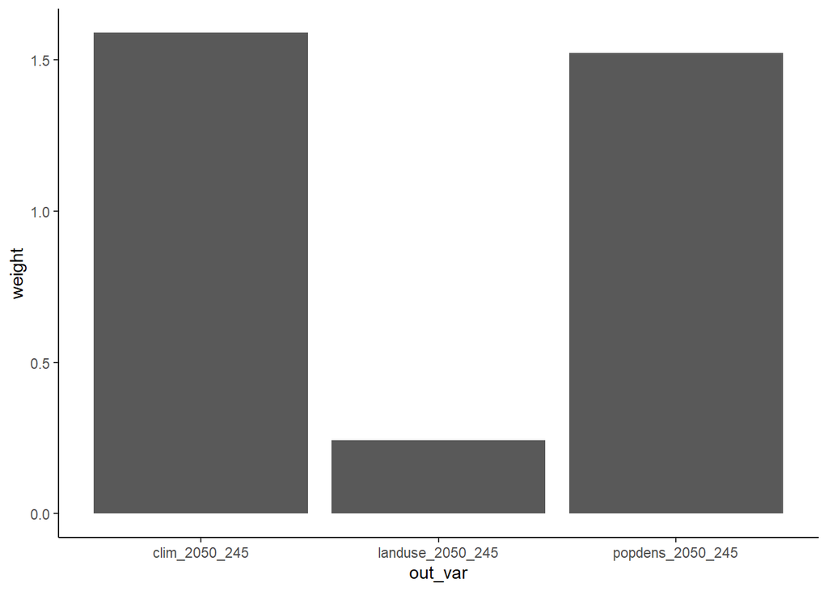

```r
# 2050_45
weight_out_df <-
  data.frame(out_var = colnames(var_out_2050_45_iucn),
             weight = weight_out_opt)

weight_in_df <-
  data.frame(out_var = rep(colnames(var_out_2050_45_iucn), 5),
             in_var = rep(colnames(var_in), each = 3),
             weight = c(weight_in_opt))

ggplot(weight_out_df, aes(out_var, weight)) +
  geom_bar(stat="identity") +
  theme_classic()
```

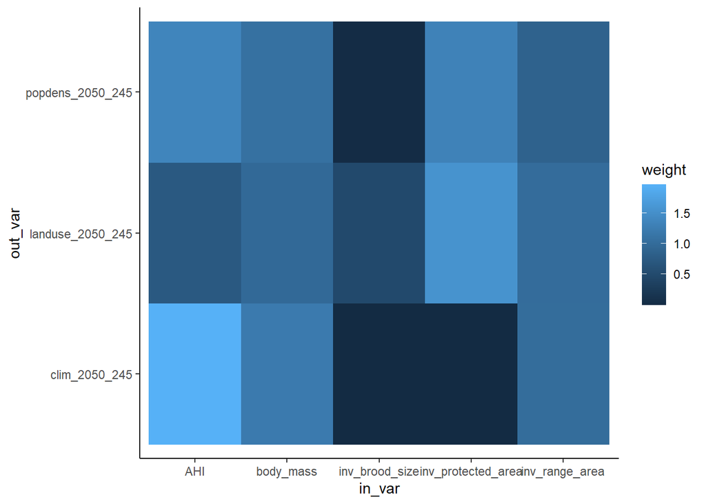

```r
ggplot(weight_in_df,
       aes(x = in_var, y = out_var, fill = weight)) +
  geom_tile() +
  theme_classic()
```

We can now use the new weights to calculate PCI for every species (including DD and NE species we had excluded before):

```r
pci_opt_2050_45 <-
  PCI::pci(sp = vert_df$binomial,
             var_out = var_out_2050_45,
             var_in = var_in,
             weight_out = weight_out_opt,
             weight_in = weight_in_opt)

head(pci_opt_2050_45[order(pci_opt_2050_45$rank),])
```

|  | sp | pci | rank |
| --- | --- | --- | --- |
| 13369 | Lycodon tessellatus | 0.8577865 | 1 |
| 9743 | Cryptoblepharus ahli | 0.8523584 | 2 |
| 493 | Arthroleptis nikeae | 0.7993735 | 3 |
| 8722 | Brachyorrhos raffrayi | 0.7453212 | 4 |
| 11493 | Gekko albofasciolatus | 0.7196880 | 5 |
| 23593 | Acrocephalus sechellensis | 0.7174734 | 6 |